# Final_Capstone-Copy1

Honore Nguessan

Data 205

Instructor: Hamman , John

WRITTEN REPORT

May 14, 2020.

```python
1.Create a title for your project

The title of my project is "MONTGOMERY COUNTY’S SALARIES DISTRIBUTION".
```

```python
2.Give an overview of your datasets

Data Source: from dataMontgomery. Website: https://data.montgomerycountymd.gov/

Datasets Content:

Employee salary 2018: 10,071 Observations with 12 variables

Employee salary 2017: 9,398 Observations with 12 variables

Employee salary 2016: 9,228 Observations with 12 variables

Variables Of Interest: Gender, Assignment Category, Current Annual salary, Gross Pay Received, and Overtime Pay

Research Goals:

Analyze the trend and variability of salary between 2016 and 2018

Evaluate the relationship between the different component of salary.
```

```python
3.Describe the data stories/insights that you discovered.
```

```python
# Importing libraires
import numpy as np
import scipy.stats as stats
import matplotlib.pyplot as plt
from matplotlib import style
import seaborn as sns
import pandas as pd
import datetime
```

```python
# Read the .CVS file
df1=pd.read_csv('salary18.csv')
print(df1)
```

```
                       Full Name Gender  2018CurrentAnnualSalary  \
0                    Lee, Tzu C.      F                107346.00
1                LeGuellec, Gael      M                128132.42
2       Lopez-Cuevas, Claudia V.      F                 85430.13
3            Maxwell, Ceciley M.      F                 65163.92
4        McAlpine-Eig, Catherine      F                133283.71
5            Mchenry, Quinton B.      M                109492.92
6            Mongelli, Teresa M.      F                100814.56
7                 Mora, Sonia E.      F                120842.43
8           Allotey, Georgina A.      F                 74548.75
9          Arnold, Jacqueline M.      F                 88761.65
10           Barefoot, Lauren G.      F                112566.00
11          Aniezue, Florence N.      F                111102.93
12         Bartlett, Florence N.      F                111102.93
13             Beckwith, Lisa G.      F                 74548.75
```

[output cut: 364 more lines]

```python
# Read the .CVS file
df2=pd.read_csv('salary17.csv')
print(df2)
```

```
                     Full Name Gender  2017CurrentAnnualSalary  \
0               Aarhus, Pam J.      F                 70959.79
1             Aaron, Marsha M.      F                110359.00
2           Ababio, Godfred A.      M                 55950.24
3               Ababu, Essayas      M                 95740.00
4           Abbamonte, Drew B.      M                 74732.00
5           Abbasian, Takin M.      M                 16451.50
6            Abdalla, Eiman M.      F                 63977.00
7       Abdelhamed, Shereen N.      F                 53274.00
8       Abdelmoniem, Marwan M.      M                 68739.36
9            Abdool, Daniel Z.      M                 50172.00
10     Abdul-Ghani, Hasinah J.      F                 50576.93
11           Abduljabar, Saeed      M                 69722.32
12    Abdur-Raheem, Mikaeel A.      M                 62248.70
13               Abebe, Emebet      F                 22938.50
```

[output cut: 364 more lines]

```python
# Read the .CVS file
df3=pd.read_csv('salary16.csv')
print(df3)
```

```
                     Full Name Gender  2016CurrentAnnualSalary  \
0               Aarhus, Pam J.      F                 69222.18
1              Aaron, David J.      M                 97392.47
2             Aaron, Marsha M.      F                104717.28
3           Ababio, Godfred A.      M                 52734.57
4               Ababu, Essayas      M                 93396.00
5           Abbamonte, Drew B.      M                 70435.00
6            Abdalla, Eiman M.      F                 60300.00
7       Abdelmoniem, Marwan M.      M                 64788.65
8            Abdool, Daniel Z.      M                 45261.00
9      Abdul-Ghani, Hasinah J.      F                 47670.09
10           Abduljabar, Saeed      M                 63492.87
11    Abdur-Raheem, Mikaeel A.      M                 58671.02
12               Abebe, Hiruth      F                152343.20
13          Abebe, Zekarias S.      M                 46626.87
```

[output cut: 364 more lines]

```python
# Read the .CVS file
df4=pd.read_csv('salary1816.csv')
print(df4)
```

```
                        Full Name  Year Gender  CurrentAnnualSalary  \
0                 LeGuellec, Gael  2018      M            128132.42
1             Mchenry, Quinton B.  2018      M            109492.92
2                 Chhuan, Phavann  2018      M            138790.00
3              Rowland, Tyrone D.  2018      M            107345.82
4                    Frey, Jon S.  2018      M            163663.00
5                  Hodge, Mark M.  2018      M            148348.80
6            Jhangiani, Sanjay N.  2018      M            107346.00
7            Jones, Calvin B. JR.  2018      M            129412.52
8                 Klinger, Dieter  2018      M            183095.80
9                   Kolb, Paul V.  2018      M             70123.14
10              Lanier, Edward H.  2018      M             72379.13
11          Kalarestaghi, Hadi K.  2018      M            183113.00
12          Martin, Ronald F. JR.  2018      M             91514.47
13              Mcclure, Scott R.  2018      M            107346.00
```

[output cut: 364 more lines]

```python
#let's start off by dropping the coulmns we will not be needing
df12 = df1.drop(["Full Name","Department","Division","Employee Position Title","Position Under-Filled"], axis=1)
```

```python
#let's start off by dropping the coulmns we will not be needing
df22 = df2.drop(["Full Name","Department","Division","Employee Position Title","Position Under-Filled"], axis=1)
```

```python
#let's start off by dropping the coulmns we will not be needing
df32 = df3.drop(["Full Name","Department","Division","Employee Position Title","Position Under-Filled"], axis=1)
```

```python
#let's start off by dropping the coulmns we will not be needing
df42 = df4.drop(["Full Name","Department","Division","Employee Position Title","Position Under-Filled"], axis=1)
```

```python
# Remove Rows With Missing Values 2016
df32.dropna(inplace=True)
print(df32)
```

```
     Gender  2016CurrentAnnualSalary  2016GrossPayReceived  2016OvertimePay  \
0         F                 69222.18              71225.98           416.10
1         M                 97392.47             103088.48          3326.19
2         F                104717.28             107000.24          1353.32
3         M                 52734.57              57819.04          3423.07
5         M                 70435.00              80926.43          9111.09
9         F                 47670.09              49336.12           275.03
10        M                 63492.87              81310.63         18163.22
11        M                 58671.02              72901.28         16565.63
13        M                 46626.87              51947.72          3556.71
14        M                 40631.32              47902.78          8556.93
15        F                 41220.18              34473.61          2244.43
16        F                 97190.31              95354.22           202.15
17        M                118400.00             119584.75           339.84
20        F                 42053.83              48548.29          8149.37
```

[output cut: 175 more lines]

```python
# Remove Rows With Missing Values 2016-2018
df42.dropna(inplace=True)
print(df42)
```

```
       Year Gender  CurrentAnnualSalary  GrossPayReceived  OvertimePay  \
0      2018      M            128132.42         125131.66         0.00
1      2018      M            109492.92         108070.31         0.00
2      2018      M            138790.00         152138.26         0.00
3      2018      M            107345.82          28699.97         0.00
4      2018      M            163663.00         163665.48         0.00
5      2018      M            148348.80         144610.69         0.00
6      2018      M            107346.00         105241.84         0.00
7      2018      M            129412.52         126501.80         0.00
8      2018      M            183095.80         186686.73         0.00
9      2018      M             70123.14          67765.97         0.00
10     2018      M             72379.13          70094.32         0.00
11     2018      M            183113.00         186705.72         0.00
12     2018      M             91514.47          89010.84         0.00
13     2018      M            107346.00         105241.84         0.00
```

[output cut: 175 more lines]

```python
# Summarizing features 2018
df12.describe()
```

|  | 2018CurrentAnnualSalary | 2018GrossPayReceived | 2018OvertimePay |
| --- | --- | --- | --- |
| count | 10071.000000 | 10071.000000 | 10071.000000 |
| mean | 78121.299247 | 79885.740105 | 6084.349689 |
| std | 30806.862164 | 38027.242415 | 11694.353945 |
| min | 11147.240000 | 0.000000 | 0.000000 |
| 25% | 54959.840000 | 55702.150000 | 0.000000 |
| 50% | 74460.000000 | 77613.580000 | 600.120000 |
| 75% | 96985.710000 | 101809.610000 | 7626.560000 |
| max | 303091.000000 | 317531.030000 | 174008.950000 |

```python
# Summarizing features 2017
df22.describe()
```

|  | 2017CurrentAnnualSalary | 2017GrossPayReceived | 2017OvertimePay |
| --- | --- | --- | --- |
| count | 9398.000000 | 9398.000000 | 9398.000000 |
| mean | 75571.149354 | 79651.300220 | 7002.141410 |
| std | 29875.189537 | 36965.189238 | 12248.709635 |
| min | 11147.240000 | 0.000000 | 0.000000 |
| 25% | 53747.000000 | 55561.675000 | 0.000000 |
| 50% | 71495.000000 | 76972.330000 | 1592.405000 |
| 75% | 95084.420000 | 101210.797500 | 9189.180000 |
| max | 303091.000000 | 315216.400000 | 125274.890000 |

```python
# Summarizing features 2016
df32.describe()
```

|  | 2016CurrentAnnualSalary | 2016GrossPayReceived | 2016OvertimePay |
| --- | --- | --- | --- |
| count | 6311.00000 | 6311.000000 | 6311.000000 |
| mean | 69264.83357 | 79520.136883 | 10335.005948 |
| std | 23942.81744 | 32742.756204 | 12677.920716 |
| min | 15969.00000 | 1408.180000 | 0.000000 |
| 25% | 51696.84500 | 57887.255000 | 1727.875000 |
| 50% | 66065.23000 | 76858.080000 | 6184.450000 |
| 75% | 86588.00000 | 98523.420000 | 14309.685000 |
| max | 174166.00000 | 251849.970000 | 125244.350000 |

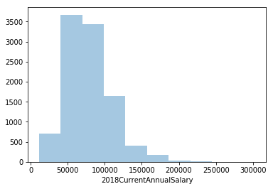

```python
sns.distplot(df12['2018CurrentAnnualSalary'], kde=False, bins=10);
```

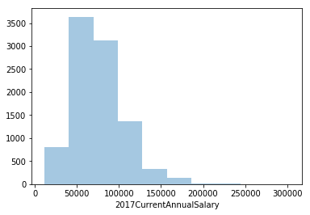

```python
sns.distplot(df22['2017CurrentAnnualSalary'], kde=False, bins=10);
```

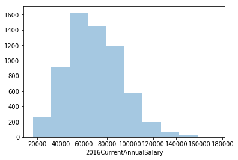

```python
sns.distplot(df32['2016CurrentAnnualSalary'], kde=False, bins=10);
```

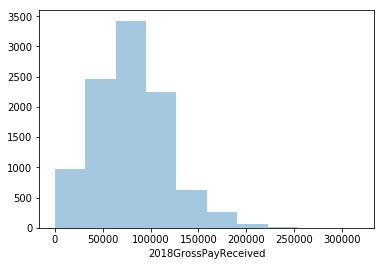

```python
sns.distplot(df12['2018GrossPayReceived'], kde=False, bins=10);
```

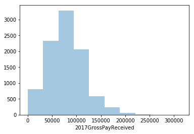

```python
sns.distplot(df22['2017GrossPayReceived'], kde=False, bins=10);
```

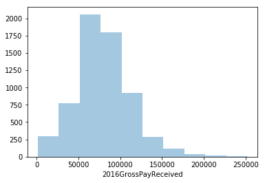

```python
sns.distplot(df32['2016GrossPayReceived'], kde=False, bins=10);
```

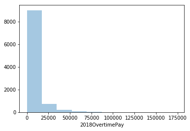

```python
sns.distplot(df12['2018OvertimePay'], kde=False, bins=10);
```

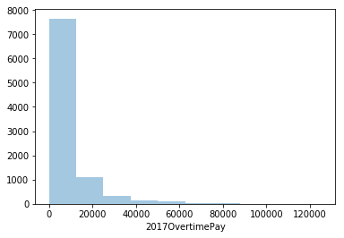

```python
sns.distplot(df22['2017OvertimePay'], kde=False, bins=10);
```

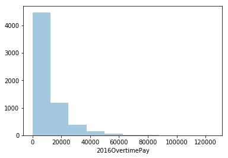

```python
sns.distplot(df32['2016OvertimePay'], kde=False, bins=10);
```

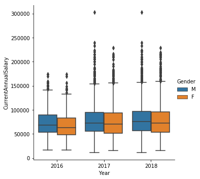

```python
sns.catplot(x="Year", y="CurrentAnnualSalary", hue="Gender", kind="box", data=df42);
```

```python
#sns.catplot(x="Year", y="CurrentAnnualSalary", hue="AssignmentCategory", kind="box", data=df42);
```

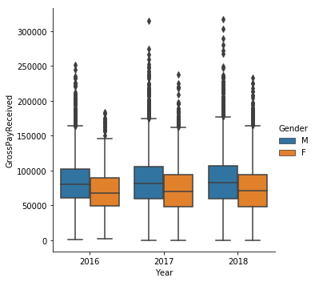

```python
sns.catplot(x="Year", y="GrossPayReceived", hue="Gender", kind="box", data=df42);
```

```python
#sns.catplot(x="Year", y="GrossPayReceived", hue="AssignmentCategory", kind="box", data=df42);
```

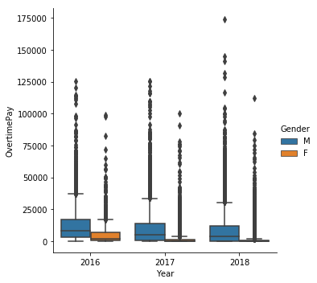

```python
sns.catplot(x="Year", y="OvertimePay", hue="Gender", kind="box", data=df42);
```

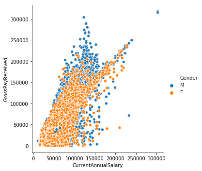

```python
sns.relplot(x="CurrentAnnualSalary", y="GrossPayReceived", hue="Gender", data=df42);
```

```python
#sns.catplot(x="Year", y="CurrentAnnualSalary", hue="Gender", kind="swarm", data=df42);
```

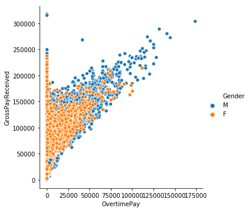

```python
sns.relplot(x="OvertimePay", y="GrossPayReceived", hue="Gender", data=df42);
```

```python
df42.corr()
```

|  | Year | CurrentAnnualSalary | GrossPayReceived | OvertimePay |
| --- | --- | --- | --- | --- |
| Year | 1.000000 | 0.114776 | 0.004031 | -0.129184 |
| CurrentAnnualSalary | 0.114776 | 1.000000 | 0.855365 | 0.114003 |
| GrossPayReceived | 0.004031 | 0.855365 | 1.000000 | 0.501473 |
| OvertimePay | -0.129184 | 0.114003 | 0.501473 | 1.000000 |

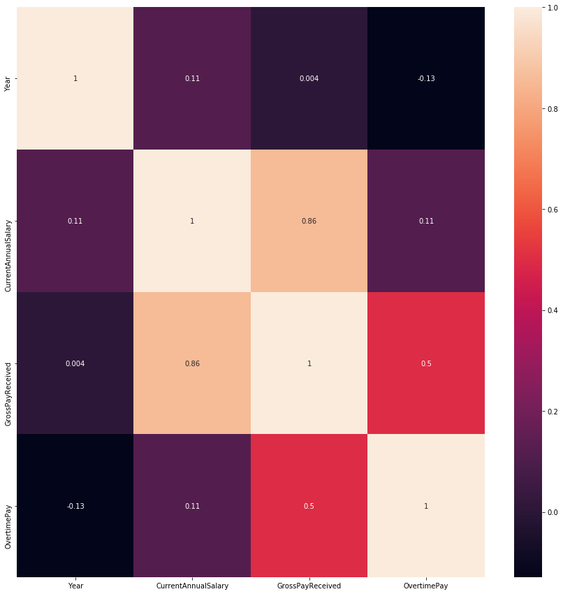

```python
# It's hard to see the correlations with small graphs and long number strings, so
#next I made a heatmap of the above correlations and annotated it for a better understanding

Var_Corr = df42.corr()
plt.figure(figsize = (15,15))
sns.heatmap(Var_Corr, xticklabels=Var_Corr.columns, yticklabels=Var_Corr.columns, annot=True)
```

SYNTHESIS OF FINDINGS

The distribution of salary is generally non symmetric with skewed to the right at all between 2016 and 2018. While the medians are slightly different in the Current Annual Salary between 2016 and 2018, the distribution for males is more highly skewed to the right, so the mean for males will be higher than the mean for females. The medians are quite a bit different in Gross Pay Received over time, the distribution for males is more highly skewed to the right, so the mean for males will be higher than the mean for females. The largest outliers in the dataset are mostly males. The Overtime Pay is mostly dominated by males between 2016 and 2018. Since the components of Gross Pay Received are Current Annual Salary and Overtime Pay, the changing in Gross Pay Received is almost influenced by males. By looking at the dataset, police officers and fire and Rescue specialists are dominant in Overtime at the all. These positions are mostly filled by males. Thus, they have the highest Gross Pay Received every year.

```python
4.Brainstorm and present three recommendations on how the data can be further “operationalized” by the public or government.

Create a column as retained tax to explain the gap between gross salary, current salary, and overtime pay;

Update the column of overtime pay;

Create a column as education (Master, Bs, AA , Certificate, other….)
```

```python
5.Acknowledgements.

Thank you:

Professor Mohamed Abdirisak and Rachel Saidi for guiding our first steps in the use of data analysis tools, such as R, Python, and Tableau to describe data stories;

Professor Hamman, John for supporting us to achieve our final project;

Professor Kathryn Linehan for bringing the greatest professors to the Data Science Certificate Program;

Dennis Linders, Montgomery County Government, and Victoria Lewis, dataMontgomery for their support and direction.
```